# Image Segmentation using Gaussian Mixture Models

## 40.319 Statistical Machine Learning | 2024 January Term

### Group Members:

- Fannisa Fahmi
- Yingrou Luo

### 1. Motivation

### 2. Context

### 3. Basic Knowledge of Gaussian Mixture Models

### 4. Gaussian Mixture Models for image segmentation

- Expectation-Maximization algorithm
- Grabcut algorithm

### 5. Applications

- Background Subtraction for video-frames
- Foreground Extraction for images

### 6. References

# 1. Motivation

If you are interested in image processing and background removal especially, Gaussian Mixture Models (GMMs) is an interesting tool to understand the algorithm behind image processing, and how can we do that in our daily lives. GMMs stands as a cornerstone in the landscape of machine learning because of its balance between simplicity and versatility. A model makes use of probability distribution has many more functions rather than clustering as we are all familiar with. If you are captivated by the challenges of unravelling complex data distribution or the art of unsupervised learning, diving into the world of GMMs is not just beneficial but essential. In image processing, GMMs can be used for tasks like image segmentation, where the goal is to identify and separate different objects within an image.

In this tutorial, you will learn the fundamentals of GMMs and how they can be used to solve real-world problems in image segmentation. You can expect to have a glance on how to build an GMMs from scratch using python.

By the end of this tutorial, you will have a robust understanding of GMMs and their applications in processing image segmentation. Armed with this knowledge and practical experience, you will be well-equipped to tackle challenges in real life. This tutorial aims to provide you with the knowledge and skills you need to start building your own GMM models and solve real-life problems. Let's delve deeper into their practical implementation and the wide spectrum of problems they can solve!

# 2. Context

In this course, we have learnt some basic classification models, such as Neural Networks for classification using the Iris dataset. In previous courses, we have also learnt k-means clustering. K-means clustering has been a foundational model in unsupervised learning models and it is capable of partitioning data into clusters or learning hierarchical representations through convolutional layers. However, it fails to discover complex non-linear data patterns. Whereas GMMs use a probabilistic assignment of data points to clusters, and this allows the model to leverage mixture models to represent complex data distributions. GMMs can generate accurate predictions for tasks such as image segmentation and speech recognition which they help in modelling the distribution of audio frequencies for different phonemes in human speech. GMMs model enables us to isolate and extract specific features or objects from images, a capability crucial for a wide range of applications, from medical imaging to automated surveillance, where distinguishing objects from the background is essential.

# 3. Basic Knowledge of Gaussian Mixture Models

First of all, we need to undertand Gaussian distribution as GMM make uses of Gausaian distribution. A Gaussian distribution is a continuous probability distribution that is characterized by its symmetrical bell shape. We are familiar with normal distribution which is also Gaussian distribution. Normal distribution has two parameters, which are the mean and standard deviation. Gaussian Mixture Models attempt to use a mixture of multi-dimensional Gaussian probability distributions that best model any input dataset. A Gaussian Mixture model has parameters that correspond to a probability that a specific data point belongs to a specific subpopulation. The probability function uses a Gaussian distribution with unknown parameters. Therefore, GMM consists of two parts which are mean vectors and covariance matrices. The picture below shows the examples of three different clusters within a dataset, it demonstrates how GMM cluster all the data points.

[figure not shown]

# 4. Gaussian Mixture Models for image segmentation

Image is a matrix which each element is pixel. The value of the pixel is a number that show intensity or color of the image. Let X be a random variable that takes these values. for a probability model, the mixture of Gaussian dsitribution is shown below: $$ f(x) = \sum_{i=1}^{n} p_i \cdot N(x | \mu_i, \sigma^2_i) $$ where k is the number of regions and the sum of weight which is represented by p. The sum of weights for each class or region. With each region, the mean and standard deviation also defer. GMM clusters pixels based on similarities in colour, texture or other low-level features, thereby partitioning the image into resonable segments. The model is based on the assumption that the intensity value of each pixel in a given image is a sample from a mixture of Gaussian distributions. $$ N(x | \mu_i, \sigma^2_i) = \frac{1}{\sqrt{2 p_i}} e^{-\frac{(x - \mu_i)^2}{2 \sigma^2_i}} $$ where mean and standard deviation are represented of each class i. Parameters are the weight, mean and standard deviation for each pixel. And these parameters are going to be furter redefined in the Expectation - Maximization algorithm.

## Expectation - Maximization Algorithm

##### The EM algorithm is designed to estimate model parameters in situation where the data is incomplete or contains hidden or unobserved variables. It consists of two iterative steps: the Expectation step and the Maximization step.

### 1. Expectation Step

The EM algorithm calculates the expected values of the missing or unobserved variables, given the current estimates of the model parameters. It computes the probabilities or responsibilities of each data point belonging to different clusters or classes, based on the current parameter estimates. The maximum likelihood estimation corresponds to calculating the probabilities for each pixel belonging to the different classes, given the current parameters and the pixel values at position x.

### 2. Maximization Step

The algorithm updates the model parameters by maximizing the likelihood of the observed data. It uses the probabilities calculated in the Expectation step to obtain a new estimate of the parameters which reduces the negative log-likelihood. This maximization step aims to find the optimal parameter values that best fit the data.

### 3. Iterative Process

The EM algorithm iteratively repeats the expectation and maximization steps until convergence is achieved. In each iteration, the algorithm refines the parameter estimates and improves the overall model fit.

## Grabcut Algorithm

##### This image segmentation algorithm uses a combination of graphical models and Gaussian Mixture Models (GMM) to differentiate between foreground and background pixels in images. It involves several steps including region drawing, ROI selection, model training, and graph segmentation.

### 1. Region Drawing

The algorithm begins by identifying the main object within an image and encasing it in a rectangle based on the foreground mask. This rectangle serves as the preliminary boundary for the region of interest (ROI). Imperfections in this initial segmentation can be manually adjusted

### 2. Region of Interest (ROI) Selection

The ROI is explicitly selected by the user, dictating the extent of foreground and background segmentation. Areas outside the ROI are automatically classified as background and visually nullified, enhancing focus on the foreground.

### 3. Gaussian Mixture Model (GMM)

GMM is applied to model the color statistics of the foreground and background. It utilizes user-provided data to learn and assign labels to pixels, effectively categorizing them based on their likelihood of belonging to the foreground or background.

### 4. Graph Generation

A graph is constructed where each pixel is represented as a node. Additional nodes, known as the Source and Sink nodes, are incorporated to represent the absolute foreground and background, respectively. Foreground pixels are connected to the Source node, and background pixels are connected to the Sink node.g

### 5. Edge Weighting

The algorithm assigns weights to the edges connecting pixels to the Source and Sink nodes. These weights are influenced by the probability of a pixel being part of the foreground or background. Lower weights are assigned where there is a significant color discrepancy, indicating a likely background association.

### 6. Graph Segmentation Algorithm

Using a cost function that aggregates the weights of the segmented edges, the algorithm separates the graph between the Source and Sink nodes. This segmentation effectively isolates the foreground from the background in the image.

### 7. Foreground-Background Labeling

After segmentation, pixels connected to the Source node are labeled as foreground, while those connected to the Sink node are labeled as background. This process is iteratively repeated as specified by the user to enhance the accuracy of the segmentation.

# 5. Applications

## Background Subtraction

Background subtraction is a technique mainly used in video processing to detect moving objects within a sequence of frames. It involves comparing each frame of the video to a model of the background to identify changes. These changes are assumed to be due to the movement of objects (foreground) in the scene. The key idea is to subtract the static background from each frame, leaving behind the moving objects. This method is particularly effective in scenarios where the camera is stationary, and the background is relatively constant, such as surveillance systems, traffic monitoring, and motion detection applications. This is used in one of the major tasks in the field of computer vision and image processing, whose aim is to detect changes in image sequences.

#### EM Algorithm for Background Substraction

The Expectation-Maximization (EM) algorithm iteratively optimizes the parameters of the Gaussian mixtures to best fit the data, which in the context of image segmentation, are the pixel values of the image. We Treat this pixel values as data points as a distribution in RGB or grayscale space.

[figure not shown]

### *Python Code*

```python
# Import Libraries needed for Background Extraction
import imageio
import numpy as np
from scipy.stats import multivariate_normal
import os
from sklearn.model_selection import train_test_split
from tqdm import tqdm
from sklearn.mixture import GaussianMixture
import cv2
import matplotlib.pyplot as plt
```

#### Data: Original Video (in .avi format)

[figure not shown]

#### Capture frames as array

```python
# Define paths
video_path = 'videos/traffic.avi'
frames_dir = 'frames/traffic'
os.makedirs(frames_dir, exist_ok=True)

# Read video
reader = imageio.get_reader(video_path)

# Extract frames
frames = []
for i, frame in enumerate(reader):
    frame = np.asarray(frame)
    frames.append(frame)
    imageio.imwrite(f'{frames_dir}/frame_{i:04d}.png', frame)  # Save frames as PNG

frames = np.array(frames)  # Convert list of frames to a numpy array

# Check if frames are loaded
if frames.size == 0:
    raise ValueError("No frames have been loaded. Check your video and path to frames.")
```

```python
# Split into training and testing sets
train_frames, test_frames = train_test_split(frames, train_size=0.6, shuffle=False)

# Output frame counts
print(f'Total frames: {frames.shape}')
print(f'Train frames: {train_frames.shape}')
print(f'Test frames: {test_frames.shape}')
```

```
Total frames: (80, 120, 160, 3)
Train frames: (48, 120, 160, 3)
Test frames: (32, 120, 160, 3)
```

#### Now, we define our GMM model calculations.

```python
# GMM Model Calculations: The EM Algorithm
def initialize_params(X, k, epsilon=1e-6):
    means = np.random.rand(k, X.shape[1])
    covars = np.array([np.eye(X.shape[1]) * epsilon for _ in range(k)])
    weights = np.full(k, 1/k)
    ric = np.zeros((X.shape[0], k))
    return means, covars, weights, ric

def e_step(X, k, means, covars, weights):
    n = X.shape[0]
    ric = np.zeros((n, k))
    for c in range(k):
        regularized_cov = covars[c] + np.eye(covars[c].shape[0]) * 1e-3  # Increased regularization
        try:
            ric[:, c] = weights[c] * multivariate_normal.pdf(X, mean=means[c], cov=regularized_cov, allow_singular=True)
        except Exception as e:
            print(f"Error in multivariate PDF calculation: {e}")
            ric[:, c] = 0
    total = np.sum(ric, axis=1, keepdims=True)
    total[total == 0] = 1  # Avoid division by zero
    ric /= total
    return ric

def m_step(X, ric, k):
    n, d = X.shape
    weights = np.sum(ric, axis=0) / n
    means = np.array([np.dot(ric[:, j], X) / (np.sum(ric[:, j]) + 1e-6) for j in range(k)])
    covars = np.array([np.dot(ric[:, j] * (X - means[j]).T, (X - means[j])) / (np.sum(ric[:, j]) + 1e-6) for j in range(k)])
    return means, covars, weights

def fit_gmm(X, k, max_iter=100, tol=1e-3):
    if np.any(np.isnan(X)) or np.any(np.isinf(X)):
        raise ValueError("Input data contains NaN or inf values.")
    means, covars, weights, ric = initialize_params(X, k)
    for _ in range(max_iter):
        ric = e_step(X, k, means, covars, weights)
        means, covars, weights = m_step(X, ric, k)
        if np.all(np.linalg.norm(means - means.copy(), axis=1) < tol):
            break
    return means, covars, weights

def predict(X, means, covars, weights):
    k = len(weights)
    gamma = np.array([weights[j] * multivariate_normal(mean=means[j], cov=covars[j]).pdf(X) for j in range(k)]).T
    return np.argmax(gamma, axis=1)
```

#### Model Training

```python
# Fit GMM to pixels and compute background
gmm_background = np.zeros((train_frames.shape[1], train_frames.shape[2], 3))

for i in tqdm(range(train_frames.shape[1])):
    for j in range(train_frames.shape[2]):
        X = train_frames[:, i, j, :]
        X = X.reshape(X.shape[0], 3)
        if np.any(np.isnan(X)) or np.any(np.isinf(X)):
            print(f"Skipping pixel ({i}, {j}) due to NaN or inf values in data.")
            continue

        means, covars, weights = fit_gmm(X, 2, max_iter=5)

        idx = np.argmax(weights)
        gmm_background[i, j, :] = means[idx]
```

#### Model Testing

The result of the Background substraction is as below. This section iterates over each frame in a video sequence stored in the test_frames array and computes the absolute difference between each frame and the background model estimated using GMM. Then, it converts the resulting difference image to grayscale and applies a threshold to classify pixels as foreground or background. Finally, it displays the resulting foreground mask using a grayscale colormap.

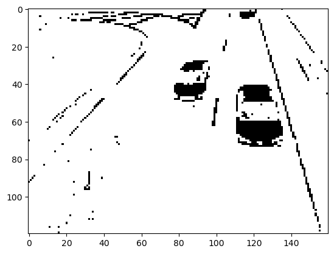

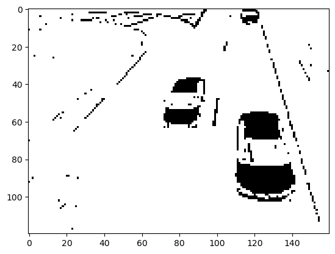

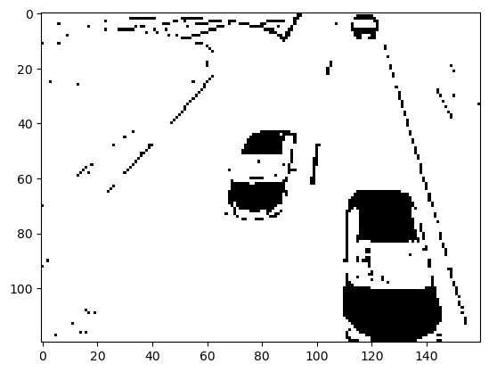

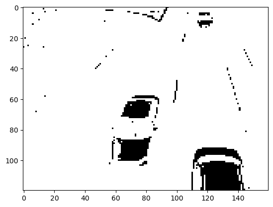

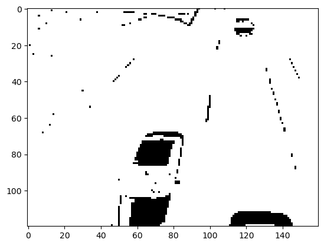

```python
# Apply to test_frames
test_frames = np.array(test_frames)
plot_counter = 0
foregrounds_list = []

# Process each frame
for i in range(test_frames.shape[0]):
    foregrounds = np.abs(test_frames[i]*255 - gmm_background*255)
    foregrounds = np.array(foregrounds, dtype='uint8')
    foregrounds = cv2.cvtColor(foregrounds, cv2.COLOR_BGR2GRAY)
    threshold = 50
    for i in range(foregrounds.shape[0]):
        for j in range(foregrounds.shape[1]):
            if foregrounds[i][j] < threshold:
                foregrounds[i][j] = 0
            else:
                foregrounds[i][j] = 255
    foregrounds_list.append(foregrounds)

    # Plot only for the first 5 frames
    if plot_counter < 5:
        plt.imshow(foregrounds, cmap='gray')
        plt.show()
        plot_counter += 1
```

#### Convert the frames result into video

The video result is in the repository on path: 'videos/result_video.avi'

```python
# Define the output video file
output_video_path = 'videos/result_video.avi'

# Define the codec and other parameters for the video writer
fourcc = cv2.VideoWriter_fourcc(*'XVID')
fps = 30.0  # Adjust the frames per second as needed
frame_width, frame_height = foregrounds_list[0].shape[1], foregrounds_list[0].shape[0]
out = cv2.VideoWriter(output_video_path, fourcc, fps, (frame_width, frame_height))

# Write processed frames into the video
for frame in foregrounds_list:
    # Convert single channel grayscale to 3-channel grayscale
    frame = cv2.cvtColor(frame, cv2.COLOR_GRAY2BGR)
    out.write(frame)

# Release the video writer
out.release()
```

```python
# Convert to gif for viewing
cap = cv2.VideoCapture('videos/result_video.avi')
if cap.isOpened():
    frames = [cv2.cvtColor(frame, cv2.COLOR_BGR2RGB) for ret, frame in iter(lambda: cap.read(), (False, None)) if ret]
    cap.release()
    # Set the loop parameter to 0 for infinite loop
    imageio.mimsave('videos/result_video.gif', frames, fps=10, loop=0)
    print("GIF created at: videos/result_video.gif")
```

```
GIF created at: videos/result_video.gif
```

#### Result of Background Subtraction

[figure not shown]

## Foreground Extraction

Foreground extraction, also known as foreground segmentation, involves identifying and isolating the main subjects or objects of interest (the foreground) from the rest of the image (the background). The goal is to accurately delineate and possibly extract the foreground elements for further processing, analysis, or editing. This is crucial in applications like object recognition, photo editing, augmented reality, and where the focus is on the objects within the scene rather than the background.

#### Grabcut Algorithm for Foreground Segmentation

GrabCut method is commonly used for foreground extraction. Starting with a user-specified bounding box around the object to be segmented, the algorithm estimates the color distribution of the target object and that of the background using a Gaussian mixture model.

#### *Python Code*

```python
# Import libraries
import cv2
import numpy as np
from sklearn.mixture import GaussianMixture
from matplotlib import pyplot as plt
```

##### Grabcut Algorithm Manual Initialization

[figure not shown]

```python
def segment_picture(path):
    img = cv2.imread(path)

    # Create a mask and bgdModel, fgdModel arrays
    mask = np.zeros(img.shape[:2], np.uint8)
    bgdModel = np.zeros((1, 65), np.float64)
    fgdModel = np.zeros((1, 65), np.float64)

    # Define the rectangle around the foreground area
    rect = (50, 50, img.shape[1]-100, img.shape[0]-100)

    # Apply GrabCut algorithm with the rectangle as the initial guess
    cv2.grabCut(img, mask, rect, bgdModel, fgdModel, 5, cv2.GC_INIT_WITH_RECT)

    # Plot original image
    plt.figure(figsize=(10, 8))
    plt.subplot(221), plt.imshow(cv2.cvtColor(img, cv2.COLOR_BGR2RGB)), plt.title('Original Image')

    # Plot initial mask after the first GrabCut application
    plt.subplot(222), plt.imshow(mask, cmap='gray'), plt.title('Initial Mask (Rectangle)')

    # Refine the mask
    refined_mask = np.where((mask == 2) | (mask == 0), 0, 1).astype('uint8')

    # Plot refined mask
    plt.subplot(223), plt.imshow(refined_mask, cmap='gray'), plt.title('Refined Mask')

    # Create a binary mask for the foreground
    bin_mask = np.where((mask == 2) | (mask == 0), 0, 1).astype('uint8')

    # Get the foreground by applying the binary mask
    img_fg = img * bin_mask[:, :, np.newaxis]

    # Set the background color (white)
    background_color = [255, 255, 255]

    # Replace the background with the specified color
    final_img = img_fg + (1 - bin_mask[:, :, np.newaxis]) * background_color

    # Convert the final image to uint8 format for display
    final_img_uint8 = final_img.astype('uint8')

    # Plot the final segmented image
    plt.subplot(224), plt.imshow(cv2.cvtColor(final_img_uint8, cv2.COLOR_BGR2RGB)), plt.title('Segmented Image')

    plt.tight_layout()
    plt.show()
```

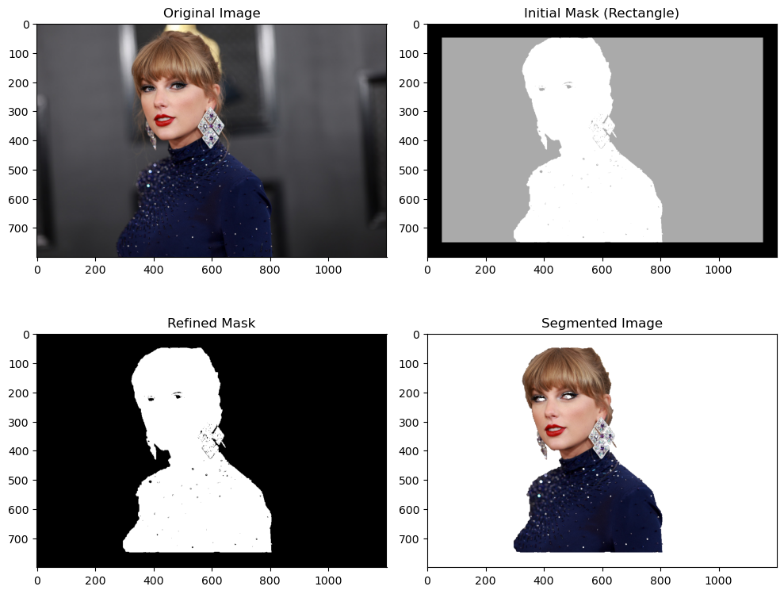

```python
segment_picture('images/taylor swift.jpg')
```

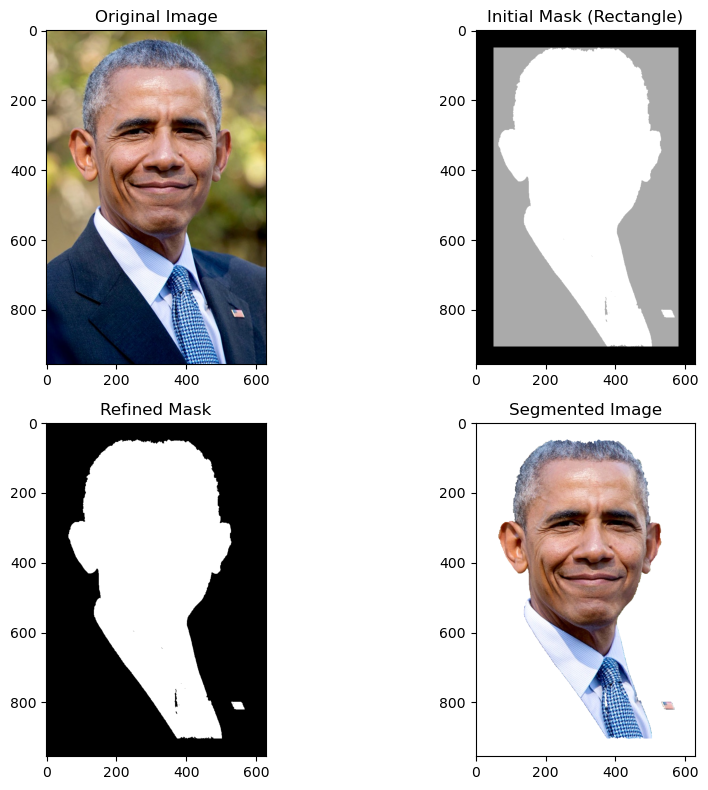

```python
segment_picture('images/obama 2.jpg')
```

The above GrabCut is initialized with a bounding box by user input. For a more accurate output or result, manual user input to refine the mask are needed which may be a disadvantage. Another way, is to provide GrabCut with additional information about the object of interest which is by binarizing the original image and labeling. Below is the refined algorithm diagram.

##### Grabcut Algorithm Automated Input (Binarized)

[figure not shown]

```python
def segment_picture_binary_match(path):
    # Read the image
    img = cv2.imread(path)

    # Convert image to grayscale
    gray_image = cv2.cvtColor(img, cv2.COLOR_BGR2GRAY)

    # Apply adaptive thresholding to binarize the grayscale image
    binarized_image = cv2.adaptiveThreshold(
        gray_image,
        maxValue=1,
        adaptiveMethod=cv2.ADAPTIVE_THRESH_GAUSSIAN_C,
        thresholdType=cv2.THRESH_BINARY,
        blockSize=9,
        C=7
    )

    # Initialize the mask based on the binarized image
    mask = np.zeros(img.shape[:2], np.uint8)
    mask[:] = cv2.GC_PR_BGD  # Assume everything is probable background
    mask[binarized_image == 0] = cv2.GC_FGD  # Set areas with black in binarized image as foreground

    # Create bgdModel, fgdModel arrays for GrabCut algorithm
    bgdModel = np.zeros((1, 65), np.float64)
    fgdModel = np.zeros((1, 65), np.float64)

    # Apply the GrabCut algorithm using the initialized mask
    cv2.grabCut(img, mask, None, bgdModel, fgdModel, 5, cv2.GC_INIT_WITH_MASK)

    # Convert mask to binary to separate foreground
    bin_mask = np.where((mask == cv2.GC_FGD) | (mask == cv2.GC_PR_FGD), 1, 0).astype('uint8')

    # Compare and refine the mask based on the initial binary mask
    refined_mask = np.where((bin_mask == 1) & (binarized_image == 1), cv2.GC_FGD, cv2.GC_PR_BGD).astype('uint8')
    refined_mask = np.where((bin_mask == 0) & (binarized_image == 0), cv2.GC_BGD, refined_mask).astype('uint8')

    # Re-apply the GrabCut algorithm with the refined mask
    cv2.grabCut(img, refined_mask, None, bgdModel, fgdModel, 5, cv2.GC_INIT_WITH_MASK)

    # Final binary mask from the refined mask
    final_bin_mask = np.where((refined_mask == cv2.GC_FGD) | (refined_mask == cv2.GC_PR_FGD), 1, 0).astype('uint8')

    # Apply the binary mask to extract the foreground
    img_fg = img * final_bin_mask[:, :, np.newaxis]

    # Set background color to white
    background_color = [255, 255, 255]

    # Replace the background with the specified color
    final_img = img_fg + (1 - final_bin_mask[:, :, np.newaxis]) * background_color

    # Convert the final image to uint8 format for display
    final_img_uint8 = final_img.astype('uint8')

    # Display results
    plt.figure(figsize=(15, 10))
    plt.subplot(231), plt.imshow(cv2.cvtColor(img, cv2.COLOR_BGR2RGB)), plt.title('Original Image')
    plt.subplot(232), plt.imshow(gray_image, cmap='gray'), plt.title('Gray Image')
    plt.subplot(233), plt.imshow(binarized_image, cmap='gray'), plt.title('Binarized Image')
    plt.subplot(234), plt.imshow(bin_mask, cmap='gray'), plt.title('Initial Mask from GrabCut')
    plt.subplot(235), plt.imshow(refined_mask, cmap='gray'), plt.title('Refined Mask')
    plt.subplot(236), plt.imshow(cv2.cvtColor(final_img_uint8, cv2.COLOR_BGR2RGB)), plt.title('Segmented Image')

    plt.tight_layout()
    plt.show()
```

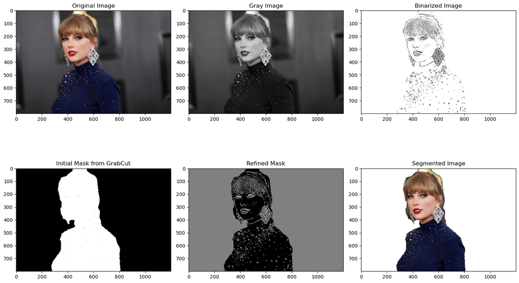

```python
segment_picture_binary_match('images/taylor swift.jpg')
```

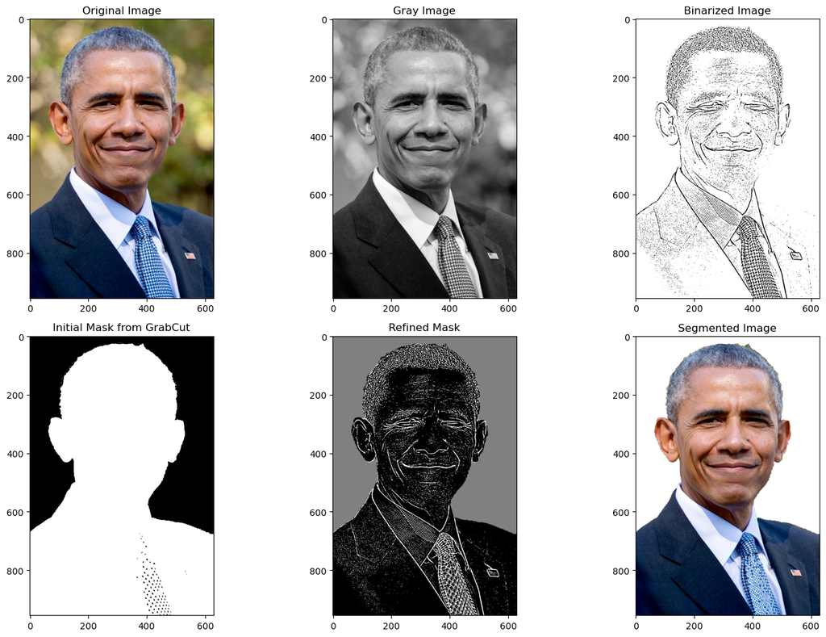

```python
segment_picture_binary_match('images/obama 2.jpg')
```

##### Result

Both model have its advantages and disadvanages. The Grabcut with combined binarized input can take in much more details, such that a less noisy pictures extract it's foreground more accurately. While, the grabcut algorithm using the general (rectangle) input initialization mask ignore noise, hence, in a more noisy picture it would actually perform better in extracting the foreground then with additional binarized input.

# 6. References

- [Bogotobogo: Image Segmentation by Foreground Extraction Using the Grabcut Algorithm](https://www.bogotobogo.com/python/OpenCV_Python/python_opencv3_Image_Segmentation_by_Foreground_Extraction_Grabcut_Algorithm_based_on_Graph_cuts.php#google_vignette)
- [OpenCV Documentation: GrabCut Algorithm](https://docs.opencv.org/3.4/d8/d83/tutorial_py_grabcut.html)
- [Python GrabCut Algorithm in an image](https://www.geeksforgeeks.org/python-foreground-extraction-in-an-image-using-grabcut-algorithm/)
- [OpenCV: Automatic Image Segmentation](https://www.sicara.fr/blog-technique/grabcut-for-automatic-image-segmentation-opencv-tutorial)
- [Gaussian Mixture Models Overview](https://mpatacchiola.github.io/blog/2020/07/31/gaussian-mixture-models.html)
- [Gaussian Mixture Models Clustering](https://www.analyticsvidhya.com/blog/2019/10/gaussian-mixture-models-clustering/)
- [Medium:Background Extraction using GMM](https://medium.com/@prantiksen4/background-extraction-from-videos-using-gaussian-mixture-models-6e11d743f932)
- [Gaussian Mixture Models: When and where to use?](https://vitalflux.com/gaussian-mixture-models-what-are-they-when-to-use/#google_vignette)
- [towardsdatascience: Use Case of GMM](https://towardsdatascience.com/3-use-cases-for-gaussian-mixture-model-gmm-72951fcf8363)
- [Gaussian Mixture Models for Background Extraction](https://github.com/akash18tripathi/Gaussian-Mixture-Models-for-Background-Extraction)